# Lecture 12

2026-05-07

## Activity 1 (Always Anonymous)

### QR Code or link

This is anonymous & optional, but helpful to Stats 20,

[figure not shown]

or here is a [direct link](https://www.menti.com/bl3ovtgc28d7)

## Example Problem #1

### replicate() vs for()

```
FUNCTION coin_toss()

        create a coin to toss
        toss the coin 10 times
        record the number of heads
        count up the number of heads
        store result

    RETURN the results

END FUNCTION
```

```r
coin_toss <- function(){
  coin <- c(1, 0) # create the coin, let head = 1 because we are counting them
  face <- sample(coin, size = 10, replace = TRUE) # simulate 10 independent tosses
  sum(face) # count them up or sum them up
}

# try it out
trials <- 10000
results_toss_replicate <- replicate(trials, coin_toss(), simplify = "vector")
head(results_toss_replicate)
```

```
[1] 6 5 6 5 7 4
```

```r
trials <- 10000
results_toss_2 <- numeric(trials) # create a vector outside of the for loop to hold results
head(results_toss_2)
```

```
[1] 0 0 0 0 0 0
```

```r
for(i in seq_len(trials)) # 1:10000 but seq_len() is considered "safer"
  {
    results_toss_2[i] <- coin_toss() # save the results
  }

head(results_toss_2)
```

```
[1] 5 6 5 6 4 4
```

```r
table(results_toss_replicate)
```

```
results_toss_replicate
   0    1    2    3    4    5    6    7    8    9   10
   8  107  394 1187 2072 2469 2058 1172  408  111   14
```

```r
table(results_toss_2)
```

```
results_toss_2
   0    1    2    3    4    5    6    7    8    9   10
   7  111  435 1160 2067 2386 2026 1261  432  111    4
```

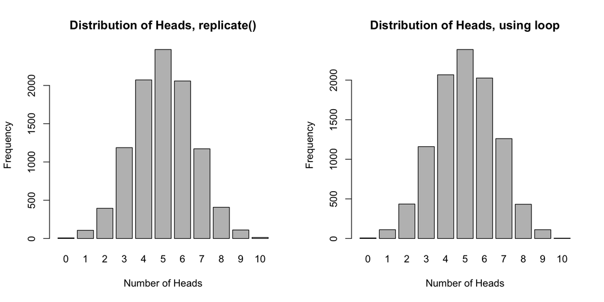

```r
opar <- par() # save the existing parameters
par(mfrow=c(1, 2))
barplot(table(results_toss_replicate),
        main = "Distribution of Heads, replicate()",
        xlab = "Number of Heads",
        ylab = "Frequency")

barplot(table(results_toss_2),
        main = "Distribution of Heads, using loop",
        xlab = "Number of Heads",
        ylab = "Frequency")
```

```r
par <- opar # I turned the warnings off, restoring original
```

## Example Problem 2 (allow arguments)

- Setup
- Replicate
- Test
- Viz
- Loop
- Test
- Viz
- How would you rewrite the coin toss simulator where you allow the function user to modify how many coins and how many trials?
- Could you program it using replicate()
- How would it differ using a for() loop?
- The Pseudocode would look something like

```
FUNCTION coin_toss2(n, trials)

    REPEAT trials:

        create a coin to toss
        toss the coin n times (user-specified)
        record the number of heads
        count up the number of heads
        store result

    RETURN the results

END FUNCTION
```

```r
coin_simulator_rep <- function(n, trials) {
  replicate(
    trials,
    sum(sample(c(0, 1), size = n, replace = TRUE))
  )
}
```

```r
outcomes2rep <- coin_simulator_rep(n = 20, trials = 1000)
table(outcomes2rep)
```

```
outcomes2rep
  3   4   5   6   7   8   9  10  11  12  13  14  15  16
  1   3  15  40  77 112 160 171 159 134  81  31  10   6
```

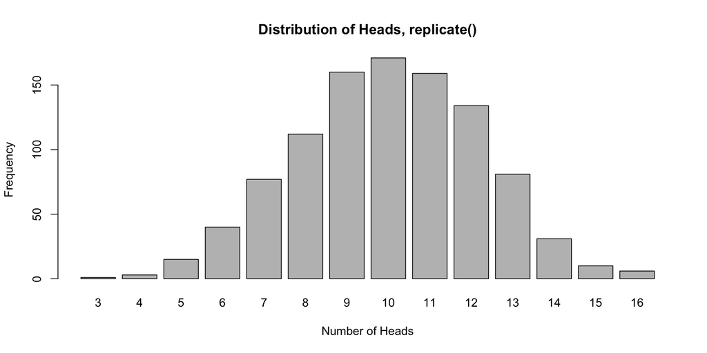

```r
barplot(table(outcomes2rep),
        main = "Distribution of Heads, replicate()",
        xlab = "Number of Heads",
        ylab = "Frequency")
```

```r
coin_simulator_loop <- function(n, trials) {

  results <- numeric(trials)

  for (i in seq_len(trials)) {
    tosses <- sample(c(0, 1), size = n, replace = TRUE)
    results[i] <- sum(tosses)
  }

  return(results)
}
```

```r
outcomes2loop <- coin_simulator_loop(n = 20, trials = 1000)
table(outcomes2loop)
```

```
outcomes2loop
  3   4   5   6   7   8   9  10  11  12  13  14  15  16  17
  2   2  18  39  74 123 143 168 174 113  83  34  17   7   3
```

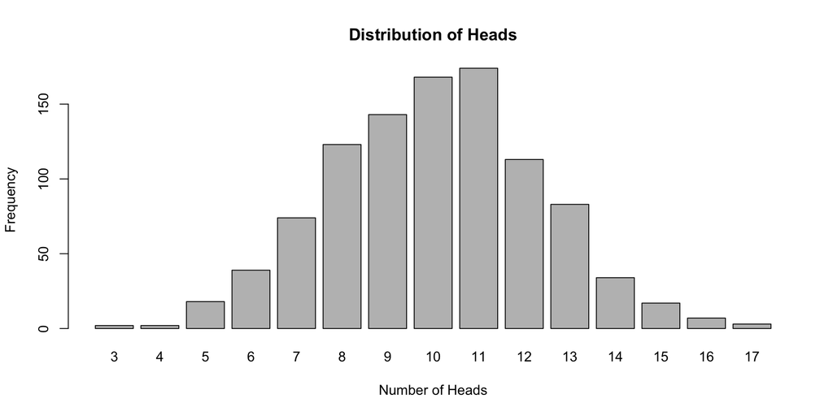

```r
barplot(table(outcomes2loop),
        main = "Distribution of Heads",
        xlab = "Number of Heads",
        ylab = "Frequency")
```

## Example 3: State Dependency

- Intro
- initialize variables
- loop
- When playing a board game like Monopoly. You roll the die to see how many spaces you move. To know what space you land on for turn 3, you must know exactly what space you were sitting on at the end of turn 2.
- The past value matters so replicate() is entirely useless here. The computer must resolve the timeline sequentially using a for().

```r
# Establish rules
number_of_turns <- 10

# Pre-allocate a vector to track board position
# (Braun & Murdoch style)
board_position <- numeric(number_of_turns)

# Set our starting state (Turn 1: start at space 0)
board_position[1] <- 0

# For teaching, keep track of the rolls
roll_value <- numeric(number_of_turns)
roll_value[1] <- 0
```

```r
# Start looping at turn 2, because turn 1 is already decided.
for (i in 2:number_of_turns) {

  # Step 1: An isolated random event (rolling the die)
  roll <- sample(1:6, size = 1)
  roll_value[i] <- roll

  # Step 2: The State Dependency
  # Current Position = Past Position + The Roll
  board_position[i] <- board_position[i - 1] + roll
}

print(roll_value)
```

```
 [1] 0 6 3 5 1 1 5 5 5 1
```

```r
print(board_position)
```

```
 [1]  0  6  9 14 15 16 21 26 31 32
```

## Timing?

- A well-written `for()` is very fast but might be more difficult to read
- A poorly-written `replicate()` will be both slower and difficult to read

```r
trials <- 100000
coin_toss <- function(){
  coin <- c(1, 0)
  face <- sample(coin, size = 10, replace = TRUE)
  sum(face)
}

system.time({
  results_replicate <- replicate(trials, coin_toss(), simplify = "vector")
})
```

```
   user  system elapsed
  0.546   0.002   0.548
```

```r
system.time({
  results_for <- numeric(trials)

  for (i in seq_len(trials)) { # seq_len for numbers
    results_for[i] <- coin_toss()
  }
})
```

```
   user  system elapsed
  0.510   0.001   0.511
```

The ‘user time’ is the computer processing time spent on your code. The ‘system time’ is the computer processing time spent by Mac or Windows on your computer to help R with what it needed. Elapsed is what you experience.

## for() loop or vectorize code?

- Vectorize when the logic is independent and contained within R
- Loop when the logic is sequential (dependent), reaches outside of R

### 1. State Dependency (Recursive Operations)

Vectorized operations assume that each calculation is independent of the others. A `for` loop is required when **iteration $i$ depends on the result of iteration $i-1$**.

- **Stochastic Simulations:** If you are building a random walk, a Markov chain, or a population model where a future state is calculated using the present state, can’t vectorize (dependent)
- **Complex Accumulation:** If the rules for accumulation change based on the running total (e.g., an account balance that incurs a penalty when it drops below a certain level), a `for` loop provides the necessary control flow.

## for() loop or vectorize code?

### 2. Working with “The Outside World”

Vectorization is designed to work with data inside R’s memory. When your want to interact with the environment outside of R the `for` loop is the correct tool.

- **File Generation:** Iterating through a list to generate and save CSV datasets to a hard drive.
- **Batch Rendering:** Looping through a large dataset to generate and save dozens of visualizations
- **Database Writes:** Adding rows or tables sequentially (slowly) into an external SQL database. Vectorization could cause the database to freeze.

## for() loop or vectorize code?

### 3. Web Scraping and API Calls

Vectorizing a request (like trying to download from multiple websites in one pass) will get your IP address banned.

- **Set the pace:** A `for` loop allows you to add a `Sys.sleep(5)` to pause between requests.
- **Error Handling:** `for` allows you check and address errors in the middle of a large transaction (e.g., downloading specific pages). A vectorized function will crash and return an error with no feedback.

### 4. Severe Memory Constraints

Vectorization uses a lot of memory. If you are working with millions of rows on a machine with standard memory (like during DataFest), a complex vectorized operation might exceed memory and crash your R session. A `for` loop, operates on one chunk of data at a time. It will be slower, but uses fewer resources

# Break

## Activity #2 Attendance

### Please Greet Your Neighbor(s)

- Practice greeting others in a safe environment. So it becomes natural.
- Reminder: You cannot receive credit if it’s only you in the photo, please refrain from photoshopping/editing photos
- Reminder: You need to upload the photo for credit.
- Please try to greet & meet a new classmate, take a photograph.

## Example problem 4: formula

- Z score! A basic statistic seen in introductory stats courses.
- We don’t really have an easy one to use, maybe you can program a Z score function for us?
- Where do you start?
- Its formula could be mapped directly to arguments in our function

$$Z = \frac{x - \mu}{\sigma}$$

- Also think of a useful/easy function name

## Programming Details

- Once you have thought through some task like our “program a Z score”, pseudocode (usually 102A) might be helpful
- Pseudocode serves as a bridge between human language and code. Use it to explain the logic of your code without going into the actual coding and its accompanying errors
- Pseudocode for this example should start with some data, compute mean, compute standard deviation, compute Z scores.